# Prediction Assignment

Vasudevan Durairaj

May 8, 2018

## Practical Machine Learning Course Project for Qualitative Activity Recognition of Weight Lifting Exercises

### Overview

This report aims to predict the Qualitative Activity Recognition of Weight lifting exercises based on a specific data set of six participants. The objective of this project is to use the data from the accelerometers on the belt, forearm, arm and dumbell of six participants wherein they had been asked to perform the barbell lifts correctly and incorrectly in five different ways and the goal is to predict the manner in which they did the exercise.

#### Background

Using devices such as Jawbone Up, Nike FuelBand, and Fitbit it is now possible to collect a large amount of data about personal activity relatively inexpensively. These type of devices are part of the quantified self movement - a group of enthusiasts who take measurements about themselves regularly to improve their health, to find patterns in their behavior, or because they are tech geeks. One thing that people regularly do is quantify how much of a particular activity they do, but they rarely quantify how well they do it.More information is available from the website here: http://web.archive.org/web/20161224072740/http:/groupware.les.inf.puc-rio.br/har(see the section on the Weight Lifting Exercise Dataset).

Read more at http://groupware.les.inf.puc-rio.br/har#ixzz3xsbS5bVX

### Data Processing & Exploratory Analysis

#### Data Set Overview

The training data for this project are available here: https://d396qusza40orc.cloudfront.net/predmachlearn/pml-training.csv

The test data are available here: https://d396qusza40orc.cloudfront.net/predmachlearn/pml-testing.csv

The data for this project come from http://web.archive.org/web/20161224072740/http:/groupware.les.inf.puc-rio.br/har. Full source: Velloso, E.; Bulling, A.; Gellersen, H.; Ugulino, W.; Fuks, H. “Qualitative Activity Recognition of Weight Lifting Exercises. Proceedings of 4th International Conference in Cooperation with SIGCHI (Augmented Human ’13)”. Stuttgart, Germany: ACM SIGCHI, 2013.

Thanks to the above mentioned authors for being so generous in allowing their data to be used for this kind of assignment.

A short description of the datasets content from the authors’ website:

“Six young health participants were asked to perform one set of 10 repetitions of the Unilateral Dumbbell Biceps Curl in five different fashions: exactly according to the specification (Class A), throwing the elbows to the front (Class B), lifting the dumbbell only halfway (Class C), lowering the dumbbell only halfway (Class D) and throwing the hips to the front (Class E).

Class A corresponds to the specified execution of the exercise, while the other 4 classes correspond to common mistakes. Participants were supervised by an experienced weight lifter to make sure the execution complied to the manner they were supposed to simulate. The exercises were performed by six male participants aged between 20-28 years, with little weight lifting experience. We made sure that all participants could easily simulate the mistakes in a safe and controlled manner by using a relatively light dumbbell (1.25kg)."

#### Data Processing

The next step is to load the dataset from the URL provided above. The training dataset is then partitioned in 2 to create a Training set (70% of the data) for the modeling process and a Test set (with the remaining 30%) for the validations. The testing dataset is not changed and will only be used for the quiz results generation.

```
## [1] 13737   160
```

```
## [1] 5885  160
```

Both created datasets have 160 variables. Those variables have plenty of NA, that can be removed with the cleaning procedures below. The Near Zero variance (NZV) variables are also removed and the ID variables as well.

```
## [1] 13737    54
```

```
## [1] 5885   54
```

After Data Cleansing, the number of variables for analysis had been reduced to 54

#### Exploratory Analysis

Correlation analysis of variables is conducted before model building procedures

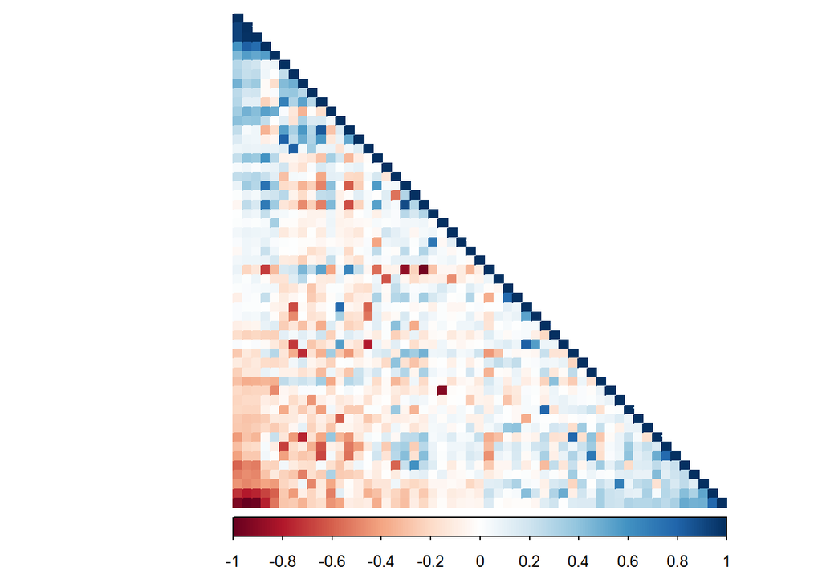

```r
cMatrix <- cor(trainSet[,-54])
corrplot(cMatrix, method = "color", order= "FPC", type = "lower", tl.col = rgb(1,1,1), tl.cex = 0.7)
```

In the graph above, the highly correlated variables are shown in dark colors. To make an even more compact analysis, a PCA (Principal Components Analysis) could be performed as pre-processing step to the datasets. Nevertheless, as the correlations are quite few, this step will not be applied for this assignment.

### Prediction Model Building

In order to build a better prediction model, three different methods will be applied to model the regressions (in the Train dataset) and the best one (with higher accuracy when applied to the Test dataset) will be used for the quiz predictions. As depicted below, Random Forests, Decision Tree and Generalized Boosted Model will be evaluated. A Confusion Matrix is plotted at the end of each analysis to better visualize the accuracy of the models and analyze the out of sample Error estimate.

#### Random Forest Method

We train a model using random forest with a cross validation of 3 folds to avoid overfitting.

```r
set.seed(34324)
## model fit
cRF <- trainControl(method = "cv", number = 3, verboseIter = FALSE)
modFitRF <- train(classe ~ ., data = trainSet, method= "rf", trControl = cRF)
modFitRF$finalModel
```

```
##
## Call:
##  randomForest(x = x, y = y, mtry = param$mtry)
##                Type of random forest: classification
##                      Number of trees: 500
## No. of variables tried at each split: 27
##
##         OOB estimate of  error rate: 0.2%
## Confusion matrix:
##      A    B    C    D    E class.error
## A 3906    0    0    0    0 0.000000000
## B    6 2648    4    0    0 0.003762227
## C    0    5 2391    0    0 0.002086811
## D    0    0    9 2243    0 0.003996448
## E    0    0    0    4 2521 0.001584158
```

```r
##prediction on Test Data Set
predRF <- predict(modFitRF,newdata=testSet)
confMatRF <- confusionMatrix(predRF, testSet$classe)
confMatRF
```

```
## Confusion Matrix and Statistics
##
##           Reference
## Prediction    A    B    C    D    E
##          A 1672    3    0    0    0
##          B    1 1134    0    0    2
##          C    0    1 1026    3    0
##          D    0    1    0  960    2
##          E    1    0    0    1 1078
##
## Overall Statistics
##
##                Accuracy : 0.9975
##                  95% CI : (0.9958, 0.9986)
##     No Information Rate : 0.2845
##     P-Value [Acc > NIR] : < 2.2e-16
##
##                   Kappa : 0.9968
##  Mcnemar's Test P-Value : NA
##
## Statistics by Class:
##
##                      Class: A Class: B Class: C Class: D Class: E
## Sensitivity            0.9988   0.9956   1.0000   0.9959   0.9963
## Specificity            0.9993   0.9994   0.9992   0.9994   0.9996
## Pos Pred Value         0.9982   0.9974   0.9961   0.9969   0.9981
## Neg Pred Value         0.9995   0.9989   1.0000   0.9992   0.9992
## Prevalence             0.2845   0.1935   0.1743   0.1638   0.1839
## Detection Rate         0.2841   0.1927   0.1743   0.1631   0.1832
## Detection Prevalence   0.2846   0.1932   0.1750   0.1636   0.1835
## Balanced Accuracy      0.9990   0.9975   0.9996   0.9976   0.9979
```

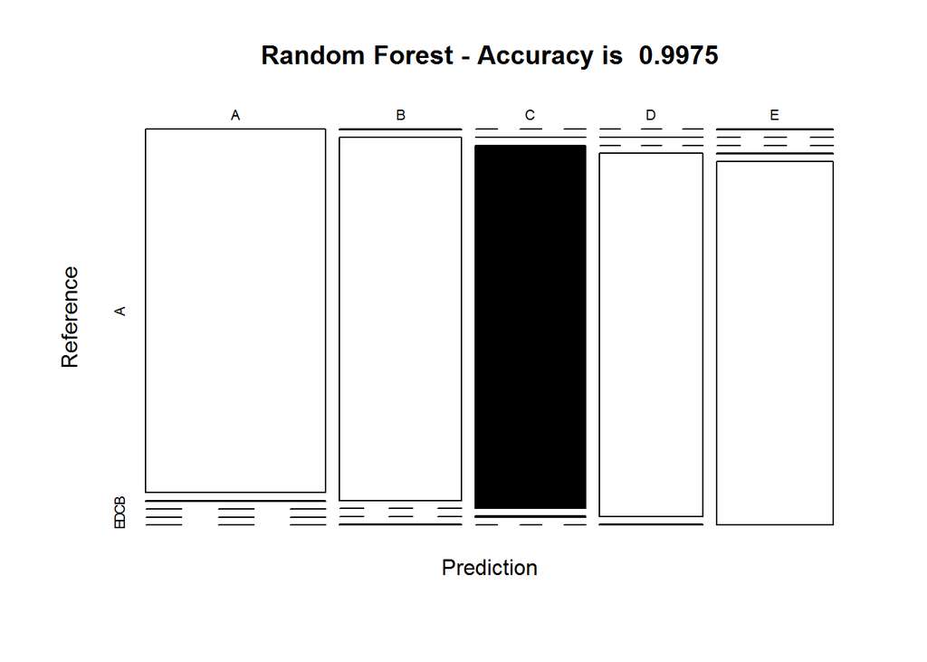

```r
##Plot the Matrix outputs
plot(confMatRF$table, col=confMatRF$byClass, main=paste("Random Forest - Accuracy is ", round(confMatRF$overall['Accuracy'],4)))
```

```r
## Out of Sample Error Estimate
accRF <- postResample(testSet$classe, predRF)
acvRF <- accRF[[1]]
ofseEst <- 1 - acvRF
ofseEst
```

```
## [1] 0.002548853
```

The estimated accuracy of the above model is 99.75% and the estimated out-of-sample error based on our fitted model applied to the cross validation dataset is 0.25%.

#### Decision Trees Method

```r
set.seed(34324)
## model fit
modFitDT <- rpart(classe ~ ., method = "class", data = trainSet)

##prediction on Test Data Set
predDT <- predict(modFitDT, newdata = testSet, type = "class")
confMatDT <- confusionMatrix(predDT, testSet$classe)
confMatDT
```

```
## Confusion Matrix and Statistics
##
##           Reference
## Prediction    A    B    C    D    E
##          A 1499  199   50   71   76
##          B   38  703   74   79  137
##          C   13   61  816  138   65
##          D   99  141   52  630  132
##          E   25   35   34   46  672
##
## Overall Statistics
##
##                Accuracy : 0.7341
##                  95% CI : (0.7226, 0.7453)
##     No Information Rate : 0.2845
##     P-Value [Acc > NIR] : < 2.2e-16
##
##                   Kappa : 0.6623
##  Mcnemar's Test P-Value : < 2.2e-16
##
## Statistics by Class:
##
##                      Class: A Class: B Class: C Class: D Class: E
## Sensitivity            0.8955   0.6172   0.7953   0.6535   0.6211
## Specificity            0.9060   0.9309   0.9430   0.9138   0.9709
## Pos Pred Value         0.7910   0.6819   0.7466   0.5977   0.8276
## Neg Pred Value         0.9561   0.9102   0.9562   0.9309   0.9192
## Prevalence             0.2845   0.1935   0.1743   0.1638   0.1839
## Detection Rate         0.2547   0.1195   0.1387   0.1071   0.1142
## Detection Prevalence   0.3220   0.1752   0.1857   0.1791   0.1380
## Balanced Accuracy      0.9007   0.7740   0.8692   0.7837   0.7960
```

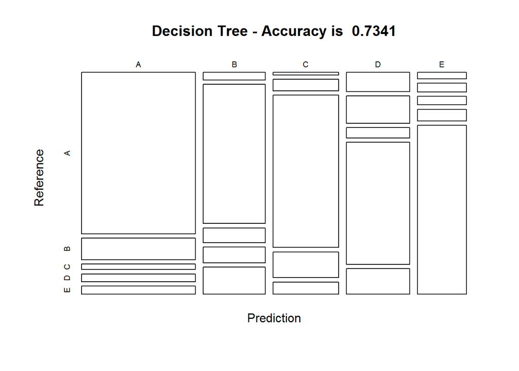

```r
##Plot the Matrix outputs
plot(confMatDT$table, col=confMatDT$byClass, main = paste("Decision Tree - Accuracy is ", round(confMatDT$overall['Accuracy'],4)) )
```

```r
## Out of Sample Error Estimate
accDT <- postResample(testSet$classe, predDT)
acvDT <- accDT[[1]]
ofseEstDT <- 1 - acvDT
ofseEstDT
```

```
## [1] 0.2659303
```

The estimated accuracy of the above model is 73.41% and the estimated out-of-sample error based on our fitted model applied to the cross validation dataset is 26.59%.

#### Generalized Boosted Model Method

```r
set.seed(34324)
## model fit
cGBM <- trainControl(method = "repeatedcv", number = 5, repeats = 1)
modFitGBM <- train(classe ~ ., data = trainSet, method = "gbm", verbose = FALSE, trControl = cGBM)
modFitGBM$finalModel
```

```
## A gradient boosted model with multinomial loss function.
## 150 iterations were performed.
## There were 53 predictors of which 43 had non-zero influence.
```

```r
##prediction on Test Data Set
predGBM <- predict(modFitGBM, newdata = testSet)
confMatGBM <- confusionMatrix(predGBM, testSet$classe)
confMatGBM
```

```
## Confusion Matrix and Statistics
##
##           Reference
## Prediction    A    B    C    D    E
##          A 1667    9    0    0    0
##          B    3 1120    4    8   10
##          C    0    8 1015    7    1
##          D    2    2    5  949    9
##          E    2    0    2    0 1062
##
## Overall Statistics
##
##                Accuracy : 0.9878
##                  95% CI : (0.9846, 0.9904)
##     No Information Rate : 0.2845
##     P-Value [Acc > NIR] : < 2.2e-16
##
##                   Kappa : 0.9845
##  Mcnemar's Test P-Value : NA
##
## Statistics by Class:
##
##                      Class: A Class: B Class: C Class: D Class: E
## Sensitivity            0.9958   0.9833   0.9893   0.9844   0.9815
## Specificity            0.9979   0.9947   0.9967   0.9963   0.9992
## Pos Pred Value         0.9946   0.9782   0.9845   0.9814   0.9962
## Neg Pred Value         0.9983   0.9960   0.9977   0.9969   0.9958
## Prevalence             0.2845   0.1935   0.1743   0.1638   0.1839
## Detection Rate         0.2833   0.1903   0.1725   0.1613   0.1805
## Detection Prevalence   0.2848   0.1946   0.1752   0.1643   0.1811
## Balanced Accuracy      0.9968   0.9890   0.9930   0.9904   0.9903
```

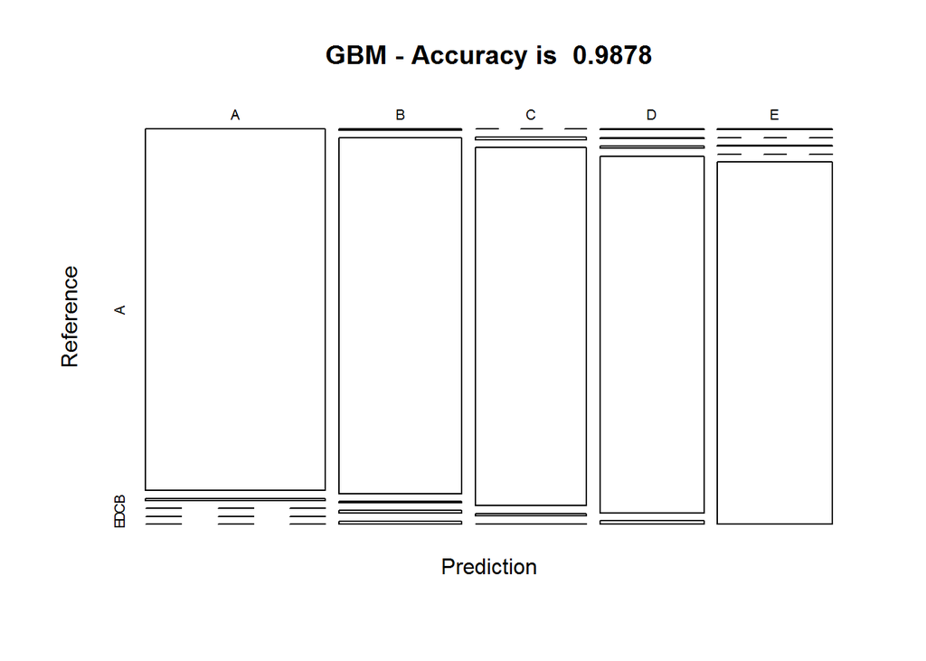

```r
##Plot the Matrix outputs
plot(confMatGBM$table, col= confMatGBM$byClass, main = paste("GBM - Accuracy is ", round(confMatGBM$overall['Accuracy'],4)))
```

```r
## Out of Sample Error Estimate
accGBM <- postResample(testSet$classe, predGBM)
acvGBM <- accGBM[[1]]
ofseEstGBM <- 1 - acvGBM
ofseEstGBM
```

```
## [1] 0.01223449
```

The estimated accuracy of the above model is 98.78% and the estimated out-of-sample error based on our fitted model applied to the cross validation dataset is 1.22%.

### Conclusion

Based on the fitment of prediction Models above, the accuracy is best in Random Forest method and hence it is applied on the testing Dataset to predict

#### Application of Predicted Model to Test Data

```r
predFinal <- predict(modFitRF, newdata = testing)
predFinal
```

```
##  [1] B A B A A E D B A A B C B A E E A B B B
## Levels: A B C D E
```